# act_report

### Virtual Analysis Report

This goal of this project is to critically look into a twitter user's page called WeRateDogs, where we plan to help analyze the users page in answering questions such as;

- What dog stage was most prominent across all images posted on the page
- User behaviour of the followers of the page across the time captured (declined/Improved)
- Most popular dogs that appeared in the page
- Relationships between followers, retweets and favourites on the page and what the influence could be.

#### Data Gathering

Three datasets were considered for this project and merged to get a master dataset used in further analysis and insight generation

- WeRateDogs twitter archive data that contains all basic tweet information
- Image prediction file that contains predictions of the dogs posted on the page
- Tweet info data that contains additional information on the tweets such as retweet count, favourites etc

#### The critical questions to be asked and the results are shown below;

#### What stage of dog was more prominent

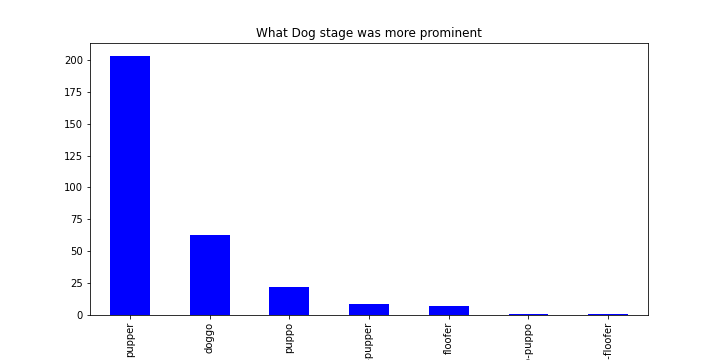

During this analysis the none values were excluded as this will skew our report negatively and are not needed for the results we are trying to achieve.

From the plot above, pupper was the most common stage among dogs displayed on WeRateDogs twitter page.

#### Trend of followers of WeRateDogs twitter account across the period the data was collected

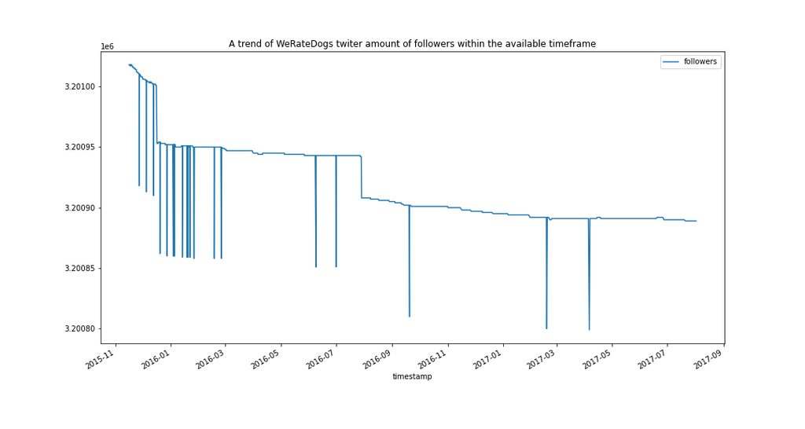

A decline in the total amount of followers was noticed across the years. This maybe one variable they might want to look at as an increase in followers will mean a wider audience reach for WeRateDogs.

#### Dog names that are most prominent in WeRateDogs twitter account

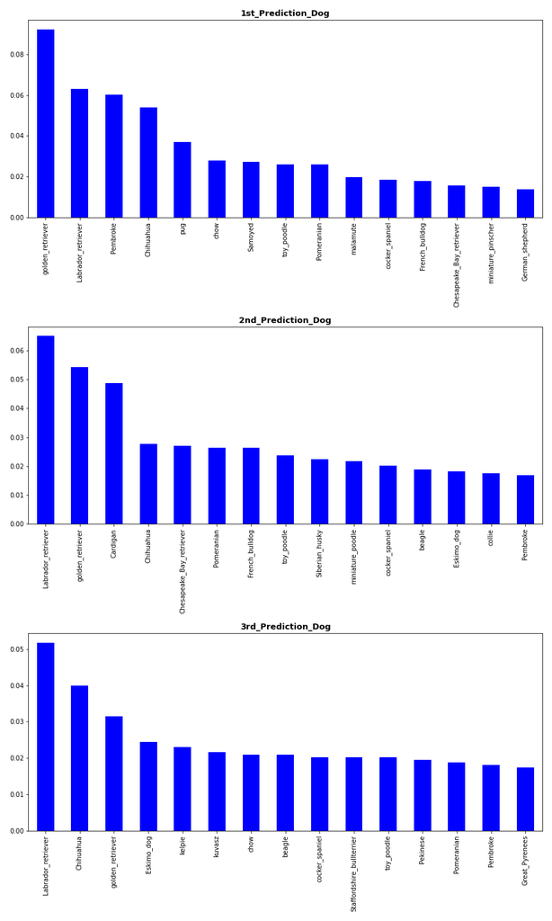

We can deduce from the above set of plots that golden_retriever and labrador_retriever are very good looking dog breed as they are prominent in the amount of appearnces in the top 3 dogs in each chart.

#### Heat map showing the relationships between retweets, favourites, followers

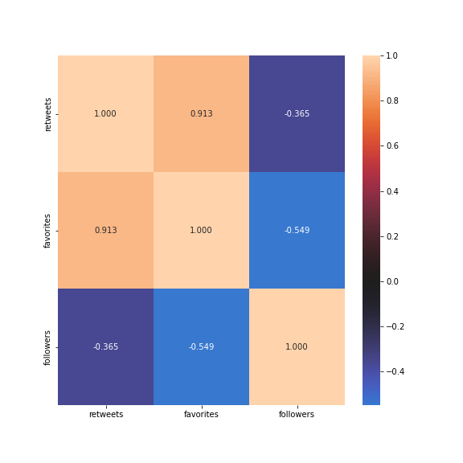

From the above heatmap, we can deduce;

favorites and retweets have a strong positive correation, therefore the more likes we get, the more retweets of that post we are likely to get.

followers is negatively correlated to both favourites and retweets, although followers has a weak negative correlation with retweets compared to favourites